# Binary Classification Using Logistic Regression Models

zhengliang

2022-06-24

## 1 Introduction

The purpose of this project was to apply what I had learnt about logistic regression and classification in machine learning (ML). It documents (1) the packages and functions that are useful for logistic classification and ML, and (2) the steps to building a logistic classification model in R.

This project focused on how to use logistic regression models in binary classification, and less about the mathematical application and theory behind it as these can be found on various websites and textbooks.

### 1.1 What is logistic regression and why is it used in classification problems?

Logistic regression is commonly used to determine the relationship between binary outcomes and one or more independent variables. The logistic regression model is written as

$$\log\bigg(\frac{p(y=1)}{1-p(y=1)}\bigg) = \beta_0 + \beta_1x_1 +
\beta_2x_2 + ... + \beta_nx_n$$
and shows a linear relationship between the independent variables and the log-odds (or logit), where the odds refers to $\frac{p}{1-p}$. The independent variables can be categorical or continuous variables. The dependent variable has only two outcomes (in general), for example yes or no, male or female, default or no default.

The coefficients of the independent variables can be interpreted as the effect of an increase in $x_n$ on the log-odds. The probability where $y=1$can also be obtained through some mathematical operations, though this can be done automatically in R. By setting a cut-off probability or threshold value, we can classify whether an observation is likely to fall under $y=1$ or $y=0$.

Logistic regression can be simple to understand and interpret, although it may not be the best classification model in comparison to more sophisticated ML algorithms.

### 1.2 What are the assumptions needed for logistic regression?

This sub-section lists the common assumptions of logistic regressions and some of the ways to check them.

#### 1.2(a) Type of logistic regression matches the response variable

The type of logit regression needs to match the type of outcome. In most cases, logit regression is used for binary outcomes but there are cases where it might be used for multinomial or ordinal outcomes and appropriate models need to be used for each type.

**To check assumption**: Check the number of unique outcomes/response variable. If there are only two outcomes, it is very likely to be a binary classification problem. If there are more than two outcomes, we are dealing with multinomial or ordinal classification problems.

#### 1.2(b) Observations are independent

Observations need to be independent of one another, and not be affected by other observations.

**To check assumption**: Plot the residuals against order of observations and check if there is a random pattern. If pattern is not random, it indicates possibility of correlation between observations. However, autocorrelation should be less of a concern with cross-sectional data as long as the design of the study ensures that data are collected from random samples and there are no repeated or paired observations.

#### 1.2(c) No multicollinearity among explanatory variables

Independent variables should not be highly correlated with one another as it affects the variance of estimated coefficients and statistical significance of estimated coefficients becomes unreliable.

**To check assumption**: A simple method would be to use a correlation matrix to find highly correlated explanatory variables. Another method is to calculate the variance inflation factor (VIF) of each explanatory variable. A common rule of thumb is that VIF more than 10 indicates problem of multicollinearity.

#### 1.2(d) Linear relationship between continuous explanatory variables and logit of response variable

Continuous explanatory variables and the logit of the response variable (or log-odds) have a linear relationship. Logit regression does not require linearity between continuous explanatory variables and response variable.

**To check assumption**: Plot log-odds against each continuous explanatory variable and check for linear relationship

#### 1.2(e) No highly influential outliers

There should be no influential outliers that could affect the outcome of the model. Removing such observations are possible if they are determined to be incorrectly entered or measured. It is also possible to compare the regression results with and without the outliers, and note how the results differ.

**To check assumption**: Calculate Cook’s Distance to find influential observations and standardized residuals to find outliers.

#### 1.2(f) Large sample size

A large sample size is needed to produce conclusive results.

## 2 Packages Required

```r
# Use install.packages("packagename") if the packages are not installed in R
library(car)
library(caret) # For building ML models
library(corrplot) # For correlation plot
library(smotefamily) # For SMOTE when there are imbalanced datasets
library(lmtest) # For statistical tests
library(mlbench) # For data sets
library(ROCR) # For determining cutoff-probability using ROC
library(ROSE) # For re-sampling techniques when there are imbalanced datasets
library(stargazer) # For neat tables and outputs, where possibles
library(tidyverse) # For ggplot and dplyr packages
```

These packages provide the necessary functions and data sets that can be used for learning and building logistic classification models.

## 3 Basics of Logistic Regression

This section covers how to perform logistic regression and solve binary classification problems using an in-built dataset.

I selected the Pima Indians Diabetes Database in the **`mlbench`** package for this example. The purpose is to determine the probability of a person having diabetes based on several variables such as the person’s body mass index, age, and blood pressure.

### 3.1 Exploratory Data Analysis

Let us first load the data and perform an Exploratory Data Analysis before the modelling task.

```r
data("PimaIndiansDiabetes")
```

```r
str(PimaIndiansDiabetes)
```

```
## 'data.frame':    768 obs. of  9 variables:
##  $ pregnant: num  6 1 8 1 0 5 3 10 2 8 ...
##  $ glucose : num  148 85 183 89 137 116 78 115 197 125 ...
##  $ pressure: num  72 66 64 66 40 74 50 0 70 96 ...
##  $ triceps : num  35 29 0 23 35 0 32 0 45 0 ...
##  $ insulin : num  0 0 0 94 168 0 88 0 543 0 ...
##  $ mass    : num  33.6 26.6 23.3 28.1 43.1 25.6 31 35.3 30.5 0 ...
##  $ pedigree: num  0.627 0.351 0.672 0.167 2.288 ...
##  $ age     : num  50 31 32 21 33 30 26 29 53 54 ...
##  $ diabetes: Factor w/ 2 levels "neg","pos": 2 1 2 1 2 1 2 1 2 2 ...
```

```r
summary(PimaIndiansDiabetes)
```

```
##     pregnant         glucose         pressure         triceps
##  Min.   : 0.000   Min.   :  0.0   Min.   :  0.00   Min.   : 0.00
##  1st Qu.: 1.000   1st Qu.: 99.0   1st Qu.: 62.00   1st Qu.: 0.00
##  Median : 3.000   Median :117.0   Median : 72.00   Median :23.00
##  Mean   : 3.845   Mean   :120.9   Mean   : 69.11   Mean   :20.54
##  3rd Qu.: 6.000   3rd Qu.:140.2   3rd Qu.: 80.00   3rd Qu.:32.00
##  Max.   :17.000   Max.   :199.0   Max.   :122.00   Max.   :99.00
##     insulin           mass          pedigree           age        diabetes
##  Min.   :  0.0   Min.   : 0.00   Min.   :0.0780   Min.   :21.00   neg:500
##  1st Qu.:  0.0   1st Qu.:27.30   1st Qu.:0.2437   1st Qu.:24.00   pos:268
##  Median : 30.5   Median :32.00   Median :0.3725   Median :29.00
##  Mean   : 79.8   Mean   :31.99   Mean   :0.4719   Mean   :33.24
##  3rd Qu.:127.2   3rd Qu.:36.60   3rd Qu.:0.6262   3rd Qu.:41.00
##  Max.   :846.0   Max.   :67.10   Max.   :2.4200   Max.   :81.00
```

```r
stargazer::stargazer(rbind(head(PimaIndiansDiabetes), tail(PimaIndiansDiabetes)),
                     type = "text",
                     title = "First and Last 6 Observations in PimaIndiansDiabetes Dataset",
                     summary = F)
```

```
##
## First and Last 6 Observations in PimaIndiansDiabetes Dataset
## ==========================================================================
##     pregnant glucose pressure triceps insulin  mass  pedigree age diabetes
## --------------------------------------------------------------------------
## 1      6       148      72      35       0    33.600  0.627   50    pos
## 2      1       85       66      29       0    26.600  0.351   31    neg
## 3      8       183      64       0       0    23.300  0.672   32    pos
## 4      1       89       66      23      94    28.100  0.167   21    neg
## 5      0       137      40      35      168   43.100  2.288   33    pos
## 6      5       116      74       0       0    25.600  0.201   30    neg
## 763    9       89       62       0       0    22.500  0.142   33    neg
## 764    10      101      76      48      180   32.900  0.171   63    neg
## 765    2       122      70      27       0    36.800  0.340   27    neg
## 766    5       121      72      23      112   26.200  0.245   30    neg
## 767    1       126      60       0       0    30.100  0.349   47    pos
## 768    1       93       70      31       0    30.400  0.315   23    neg
## --------------------------------------------------------------------------
```

By entering `??PimaIndiansDiabetes` into the console, we can get a description of the variables in the data frame. I have listed the variables and its description in the table below.

| Variable | Description |
| --- | --- |
| pregnant | Number of times pregnant |
| glucose | Plasma glucose concentration (glucose tolerance test) |
| pressure | Diastolic blood pressure (mm Hg) |
| triceps | Triceps skin fold thickness (mm) |
| insulin | 2-Hour serum insulin (mu U/ml) |
| mass | Body mass index (weight in kg/(height in m)^2) |
| pedigree | Diabetes pedigree function |
| age | Age (years) |
| diabetes | Class variable (test for diabetes) |

The **`str`** function shows that there are 768 observations with 9 variables and only the variable *`diabetes`* is a factor while all other variables are numeric.

The **`summary`** function reveals that there are possibly some errors in the data, with value of zero in variables *`glucose`*, *`pressure`*, *`triceps`*, and *`mass`*. I would remove these observations to keep things simple. The imputation of these variables would require methods beyond using the mean or median of each variable.

```r
data <- PimaIndiansDiabetes %>%
  dplyr::filter(glucose != 0 & pressure != 0 & triceps != 0 & mass != 0)

summary(data)
```

```
##     pregnant         glucose          pressure         triceps
##  Min.   : 0.000   Min.   : 56.00   Min.   : 24.00   Min.   : 7.00
##  1st Qu.: 1.000   1st Qu.: 98.75   1st Qu.: 64.00   1st Qu.:22.00
##  Median : 2.000   Median :115.00   Median : 72.00   Median :29.00
##  Mean   : 3.517   Mean   :121.03   Mean   : 71.51   Mean   :29.18
##  3rd Qu.: 5.000   3rd Qu.:141.25   3rd Qu.: 80.00   3rd Qu.:36.00
##  Max.   :17.000   Max.   :199.00   Max.   :110.00   Max.   :99.00
##     insulin           mass          pedigree           age        diabetes
##  Min.   :  0.0   Min.   :18.20   Min.   :0.0850   Min.   :21.00   neg:355
##  1st Qu.:  0.0   1st Qu.:27.88   1st Qu.:0.2587   1st Qu.:23.00   pos:177
##  Median : 91.5   Median :32.80   Median :0.4160   Median :28.00
##  Mean   :115.0   Mean   :32.89   Mean   :0.5030   Mean   :31.61
##  3rd Qu.:165.2   3rd Qu.:36.90   3rd Qu.:0.6585   3rd Qu.:38.00
##  Max.   :846.0   Max.   :67.10   Max.   :2.4200   Max.   :81.00
```

It seems that *`insulin`* has values of zero as well, which could be due to not receiving insulin despite having diabetes. Removing these observations might impact the results and analysis.

Now that there is a better understanding of the variables in the dataset, I would plot these variables to visualize their distribution.

```r
response <- subset(data, select = c(diabetes))

explvar <- subset(data, select = -c(diabetes))

summary(response)
```

```
##  diabetes
##  neg:355
##  pos:177
```

```r
summary(explvar)
```

```
##     pregnant         glucose          pressure         triceps
##  Min.   : 0.000   Min.   : 56.00   Min.   : 24.00   Min.   : 7.00
##  1st Qu.: 1.000   1st Qu.: 98.75   1st Qu.: 64.00   1st Qu.:22.00
##  Median : 2.000   Median :115.00   Median : 72.00   Median :29.00
##  Mean   : 3.517   Mean   :121.03   Mean   : 71.51   Mean   :29.18
##  3rd Qu.: 5.000   3rd Qu.:141.25   3rd Qu.: 80.00   3rd Qu.:36.00
##  Max.   :17.000   Max.   :199.00   Max.   :110.00   Max.   :99.00
##     insulin           mass          pedigree           age
##  Min.   :  0.0   Min.   :18.20   Min.   :0.0850   Min.   :21.00
##  1st Qu.:  0.0   1st Qu.:27.88   1st Qu.:0.2587   1st Qu.:23.00
##  Median : 91.5   Median :32.80   Median :0.4160   Median :28.00
##  Mean   :115.0   Mean   :32.89   Mean   :0.5030   Mean   :31.61
##  3rd Qu.:165.2   3rd Qu.:36.90   3rd Qu.:0.6585   3rd Qu.:38.00
##  Max.   :846.0   Max.   :67.10   Max.   :2.4200   Max.   :81.00
```

Let us take a look at the distribution of the response and explvar variables in a univariate plot. This gives us a visual understanding of how the variables are distributed individually.

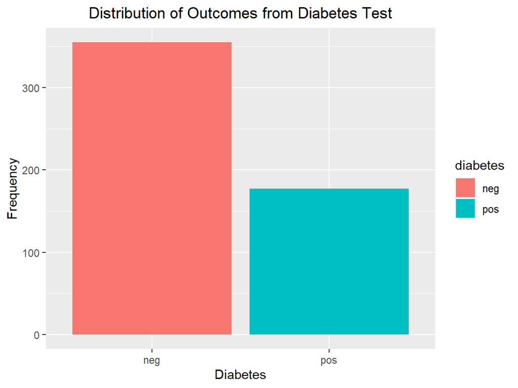

```r
ggplot(data = response) +
  geom_bar(aes(x = diabetes, fill = diabetes)) +
  ggtitle("Distribution of Outcomes from Diabetes Test") +
  xlab("Diabetes") + ylab("Frequency") +
  theme(plot.title = element_text(hjust = 0.5))
```

We have about twice as many negative observations compared to positive observations. While this may not be a problem in our case, it would be good to think about the representation of observations in a more complex dataset. Under-representation of any group in an analysis may lead to unreliable results and prediction.

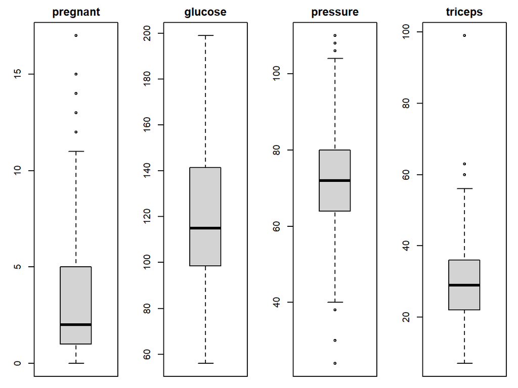

```r
par(mfrow = c(1, 4), mar = c(1, 3, 2, 1))

for (i in 1:4) {
  boxplot(explvar[,i], main = names(explvar)[i])
}
```

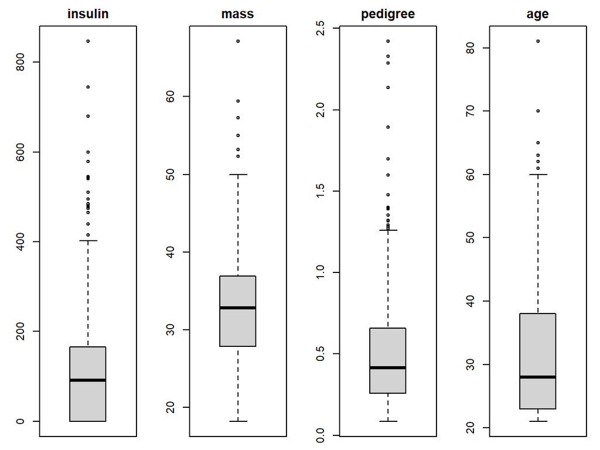

```r
for (i in 5:8) {
  boxplot(explvar[,i], main = names(explvar)[i])
}
```

Plotting the explanatory variables using histograms allow us to visually check how the data is distributed. The plots show that most variables do not have a normal distribution, which we can further check with the Shapiro-Wilk’s test.

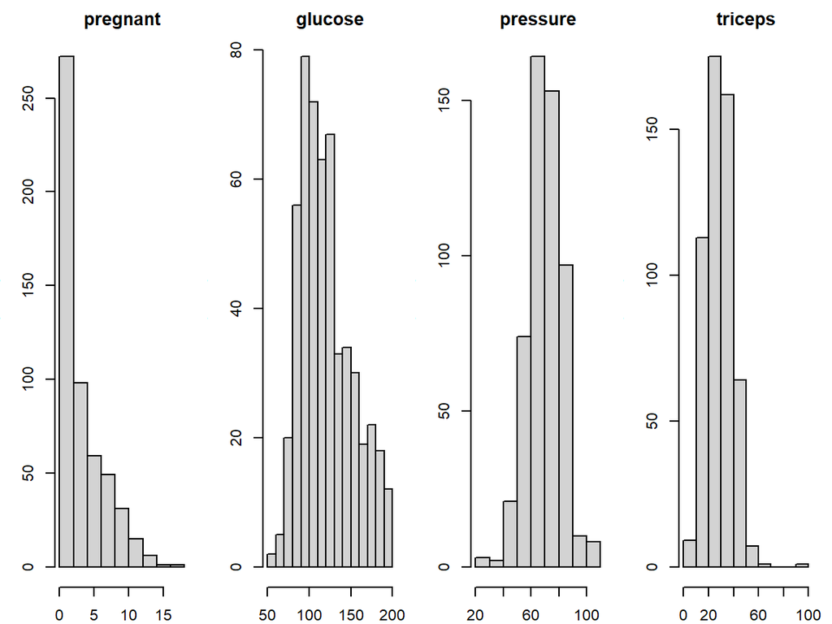

```r
par(mfrow = c(1, 4), mar = c(2, 3, 2, 1))

for (i in 1:4) {
  hist(explvar[,i], main = names(explvar)[i])
}
```

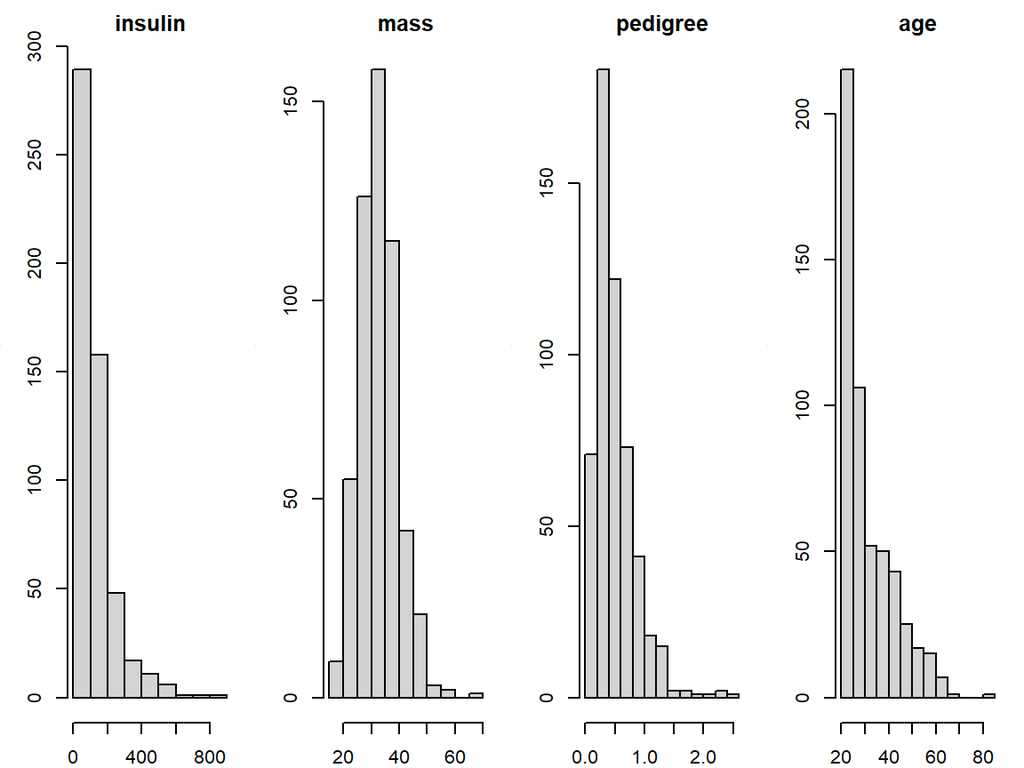

```r
for (i in 5:8) {
  hist(explvar[,i], main = names(explvar)[i])
}
```

```r
store_test <- list()

for (i in 1:8) {
  store_test <- cbind(store_test,
                      shapiro.test(x = explvar[,i]))
}

store_test["data.name",] <- names(explvar)

store_test
```

```
##           [,1]                          [,2]
## statistic 0.872964                      0.9578421
## p.value   2.031706e-20                  3.345494e-11
## method    "Shapiro-Wilk normality test" "Shapiro-Wilk normality test"
## data.name "pregnant"                    "glucose"
##           [,3]                          [,4]
## statistic 0.9897135                     0.9679037
## p.value   0.0008825611                  2.177388e-09
## method    "Shapiro-Wilk normality test" "Shapiro-Wilk normality test"
## data.name "pressure"                    "triceps"
##           [,5]                          [,6]
## statistic 0.8190614                     0.9775756
## p.value   5.138553e-24                  2.782579e-07
## method    "Shapiro-Wilk normality test" "Shapiro-Wilk normality test"
## data.name "insulin"                     "mass"
##           [,7]                          [,8]
## statistic 0.8447408                     0.8539208
## p.value   2.022287e-22                  8.407239e-22
## method    "Shapiro-Wilk normality test" "Shapiro-Wilk normality test"
## data.name "pedigree"                    "age"
```

```r
store_test["p.value",] > 0.05
```

```
## [1] FALSE FALSE FALSE FALSE FALSE FALSE FALSE FALSE
```

We can use multivariate plots to visualize how variables interact with one another. Using a correlation matrix heatmap, we can visualize the correlation between variables and check for the presence of multicollinearity between explanatory variables. Since the Shapiro-Wilk’s test rejected the hypothesis of normal distribution for the explanatory variables, I would use the Spearman correlation instead of Pearson correlation.

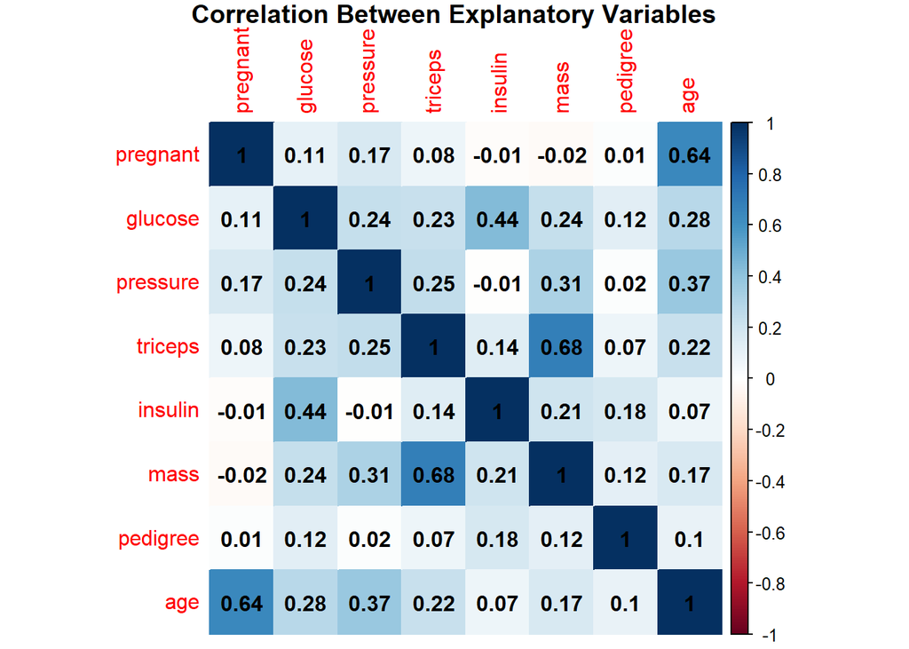

```r
corrX <- cor(x = explvar, method = "spearman")

corrplot(corr = corrX,
         method = "color",
         addCoef.col = "black",
         title = "Correlation Between Explanatory Variables",
         mar = c(0, 0, 1, 0))
```

From the correlation matrix, there does not seem to be any highly correlated explanatory variables, which may satisfy our assumption that there is no multicollinearity.

Now that we have a better understanding of the variables in the dataset, we can proceed with the modelling process.

### 3.2 Building the Binary Logistic Regression Model

To start off, we can create a logistic regression model that uses all the explanatory variables. We need to use the **`glm`** function and for the **`family`** argument, we indicate `binomial(link = "logit")` for logistic regression.

```r
# Full model
model1 <- glm(diabetes == "pos" ~ ., #indicate "pos" so that it is 1 and "neg" is 0
              data = data,
              family = binomial(link = "logit"))

stargazer::stargazer(model1,
                     type = "text",
                     title = "Logit Regression Output for Full Model")
```

```
##
## Logit Regression Output for Full Model
## =============================================
##                       Dependent variable:
##                   ---------------------------
##                        diabetes == "pos"
## ---------------------------------------------
## pregnant                   0.121***
##                             (0.044)
##
## glucose                    0.037***
##                             (0.005)
##
## pressure                    -0.009
##                             (0.010)
##
## triceps                      0.006
##                             (0.015)
##
## insulin                     -0.001
##                             (0.001)
##
## mass                       0.086***
##                             (0.024)
##
## pedigree                   1.336***
##                             (0.366)
##
## age                         0.026*
##                             (0.014)
##
## Constant                   -9.678***
##                             (1.005)
##
## ---------------------------------------------
## Observations                  532
## Log Likelihood             -232.615
## Akaike Inf. Crit.           483.230
## =============================================
## Note:             *p<0.1; **p<0.05; ***p<0.01
```

The coefficients (or “Estimate” in the regression output) of the explanatory variables refers to the effect on the log-odds and not the probability itself.

Variables *`pressure`*, *`triceps`*, *`insulin`*, and *`age`* has p-values more than the significance level of 5%. We may consider removing them from the equation and see if we get better results. The Likelihood Ratio test will be needed to test if the difference is significant, which is something like an F-test for Ordinary Least Squares regression models. The null hypothesis is that the full model and the restricted model fits the data equally well and we should use the restricted model. The alternative is to use the full model.

```r
# Restricted model
model2 <- glm(diabetes == "pos" ~ pregnant + glucose + mass + pedigree,
              data = data,
              family = binomial(link = "logit"))

stargazer::stargazer(model2,
                     type = "text",
                     title = "Logit Regression Output for Restricted Model")
```

```
##
## Logit Regression Output for Restricted Model
## =============================================
##                       Dependent variable:
##                   ---------------------------
##                        diabetes == "pos"
## ---------------------------------------------
## pregnant                   0.173***
##                             (0.034)
##
## glucose                    0.036***
##                             (0.004)
##
## mass                       0.084***
##                             (0.018)
##
## pedigree                   1.362***
##                             (0.362)
##
## Constant                   -9.449***
##                             (0.875)
##
## ---------------------------------------------
## Observations                  532
## Log Likelihood             -235.148
## Akaike Inf. Crit.           480.296
## =============================================
## Note:             *p<0.1; **p<0.05; ***p<0.01
```

```r
lmtest::lrtest(model2, model1)
```

```
## Likelihood ratio test
##
## Model 1: diabetes == "pos" ~ pregnant + glucose + mass + pedigree
## Model 2: diabetes == "pos" ~ pregnant + glucose + pressure + triceps +
##     insulin + mass + pedigree + age
##   #Df  LogLik Df  Chisq Pr(>Chisq)
## 1   5 -235.15
## 2   9 -232.62  4 5.0663     0.2806
```

Since the **`lrtest`** function returned a p-value more than 5%, we do not reject the null and hence, we will use the restricted model for our analysis.

#### 3.2(a) Testing Multicollinearity Assumption

In Section 3.1 Exploratory Data Analysis, I used the correlation matrix to determine if there are any highly correlated explanatory variables. Another method is to use the Variance Inflation Factor.

```r
car::vif(model2)
```

```
## pregnant  glucose     mass pedigree
## 1.033636 1.011338 1.026758 1.013449
```

None of the variables has a VIF of more than 10. Therefore, it is likely that there is no multicollinearity among the explanatory variables.

#### 3.2(b) Testing Linearity Assumption

To check if there is a linear relationship between the continuous explanatory variables and the logit of the response variable, we need to obtain the fitted probabilities from our model. The **`fitted.values`** function returns the probability and not the log-odds.

```r
prob.model2 <- fitted.values(model2)

head(prob.model2)
```

```
##          1          2          4          5          7          9
## 0.66178457 0.03056138 0.03121139 0.90844224 0.04163681 0.70424815
```

```r
pred <- names(coef(model2)[-1]) # Exclude intercept

plotdata <- subset(data, select = pred) # Only keep the variables used in the model

plotdata <- plotdata %>%
  mutate(logit = log(prob.model2/(1-prob.model2))) %>% # Bind logit to plotdata
  gather(key = "pred", value = "pred.value", -logit)
```

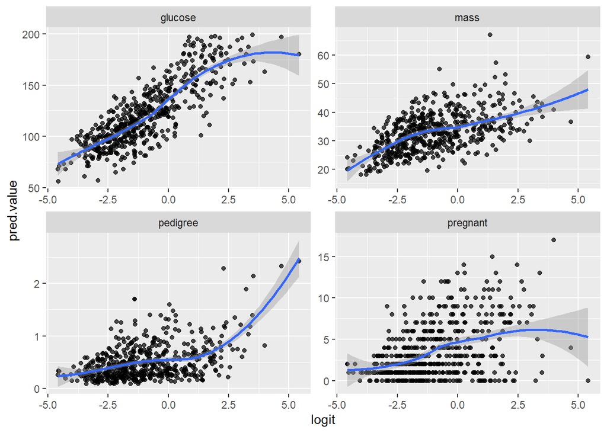

```r
ggplot(data = plotdata, aes(x = logit, y = pred.value)) +
  geom_point(alpha = 0.7) +
  geom_smooth(method = "loess") +
  facet_wrap(. ~ pred, scales = "free")
```

We can see that variables *`glucose`*, *`mass`* and *`pregnant`* are have a rather linear relationship, but *`pedigree`* has a non-linear relationship with the log-odds. I have attempted to transform the variable using the natural log.

```r
model3 <- glm(diabetes == "pos" ~ pregnant + glucose + mass + log(pedigree),
              data = data,
              family = binomial(link = "logit"))

stargazer::stargazer(model3,
                     type = "text",
                     title = "Logit Regression Output for Model With Transformed Variable")
```

```
##
## Logit Regression Output for Model With Transformed Variable
## =============================================
##                       Dependent variable:
##                   ---------------------------
##                        diabetes == "pos"
## ---------------------------------------------
## pregnant                   0.174***
##                             (0.035)
##
## glucose                    0.036***
##                             (0.004)
##
## mass                       0.084***
##                             (0.018)
##
## log(pedigree)              0.790***
##                             (0.194)
##
## Constant                   -8.058***
##                             (0.841)
##
## ---------------------------------------------
## Observations                  532
## Log Likelihood             -233.774
## Akaike Inf. Crit.           477.548
## =============================================
## Note:             *p<0.1; **p<0.05; ***p<0.01
```

```r
prob.model3 <- fitted.values(model3)

logit = log(prob.model3/(1-prob.model3))
```

```r
plotdata2 <- subset(data, select = pred)

plotdata2 <- plotdata2 %>%
  mutate(l.pedigree = log(pedigree))
```

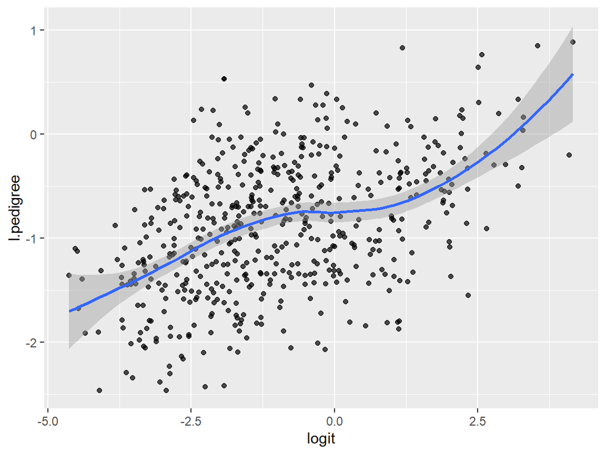

```r
ggplot(data = plotdata2, aes(x = logit, y = l.pedigree)) +
  geom_point(alpha = 0.7) +
  geom_smooth(method = "loess")
```

After the log transformation, *`pedigree`* has a more linear relationship with the log-odds compared to before.

#### 3.2(c) Checking for Highly Influential Outliers

This requires that we find outliers that are highly influential. To determine the observations that have the highest influence, we can plot the Cook’s Distance generated from the model or calculate them using **`cooks.distance`** function. To determine the outliers, we use the standardized residuals and check if there are any observations with absolute values greater than 3. We can also use the **`outlierTest`** function in the **`car`** package to calculate the studentized residuals.

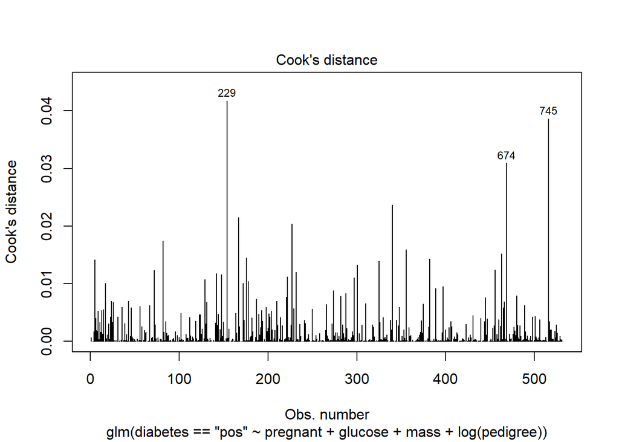

```r
plot(model3, which = 4)
```

```r
head(sort(cooks.distance(model3), decreasing = T))
```

```
##        229        745        674        488        248        329
## 0.04174376 0.03862074 0.03089600 0.02363129 0.02148044 0.02040472
```

```r
std.resid <- rstandard(model3)

val <- abs(std.resid) > 3

table(val)["TRUE"] # Returned NA because there are no TRUE logical values
```

```
## <NA>
##   NA
```

```r
car::outlierTest(model3)
```

```
## No Studentized residuals with Bonferroni p < 0.05
## Largest |rstudent|:
##      rstudent unadjusted p-value Bonferroni p
## 229 -2.711258          0.0067028           NA
```

I had found no outliers that were highly influential based on the tests that were conducted. If outliers were found, instead of removing them, it is better to investigate these observations to check if they were erroneously measured or recorded.

## 4 Evaluating the Models

Now that we have created a few models, we can evaluate how each model performs in predicting the in-sample observations. We first store the fitted values of different models and I will set the cutoff at 0.5 to determine whether an observation would be positive or negative to make things simple for now.

### Model 1: Full Model

```r
prob.model1 <- fitted.values(model1) #can also use predict(model1, type="response")
```

```r
prediction.model1 <- as.factor(ifelse(prob.model1 > 0.5, "pos", "neg"))

confusionMatrix(data = prediction.model1,
                reference = data$diabetes,
                dnn = c("Predicted", "Actual"),
                positive = "pos", mode = "everything")
```

```
## Confusion Matrix and Statistics
##
##          Actual
## Predicted neg pos
##       neg 316  76
##       pos  39 101
##
##                Accuracy : 0.7838
##                  95% CI : (0.7464, 0.8181)
##     No Information Rate : 0.6673
##     P-Value [Acc > NIR] : 2.239e-09
##
##                   Kappa : 0.4862
##
##  Mcnemar's Test P-Value : 0.0007879
##
##             Sensitivity : 0.5706
##             Specificity : 0.8901
##          Pos Pred Value : 0.7214
##          Neg Pred Value : 0.8061
##               Precision : 0.7214
##                  Recall : 0.5706
##                      F1 : 0.6372
##              Prevalence : 0.3327
##          Detection Rate : 0.1898
##    Detection Prevalence : 0.2632
##       Balanced Accuracy : 0.7304
##
##        'Positive' Class : pos
##
```

`model1` was able to predict 316 negatives that are actually negatives (True Negatives) and predict 101 positives that are actually positive (True Positives). It predicted 76 negatives when they are actually positive observations (False Negatives) and predicted 39 positive observations when they are actually negative (False Positives). Since this is a model to predict whether a person is diabetic, the 76 false negatives could be a more serious problem as it would result in life-threatening situations. The 39 false positive could be lowered, but there is always a trade-off in using prediction models and we should also consider the costs involved in real-life situations.

### Model 2: Restricted Model (Not Transformed)

```r
prediction.model2 <- as.factor(ifelse(prob.model2 > 0.5, "pos", "neg"))

confusionMatrix(data = prediction.model2,
                reference = data$diabetes,
                dnn = c("Predicted", "Actual"),
                positive = "pos", mode = "everything")
```

```
## Confusion Matrix and Statistics
##
##          Actual
## Predicted neg pos
##       neg 321  73
##       pos  34 104
##
##                Accuracy : 0.7989
##                  95% CI : (0.7623, 0.8321)
##     No Information Rate : 0.6673
##     P-Value [Acc > NIR] : 1.273e-11
##
##                   Kappa : 0.5206
##
##  Mcnemar's Test P-Value : 0.0002392
##
##             Sensitivity : 0.5876
##             Specificity : 0.9042
##          Pos Pred Value : 0.7536
##          Neg Pred Value : 0.8147
##               Precision : 0.7536
##                  Recall : 0.5876
##                      F1 : 0.6603
##              Prevalence : 0.3327
##          Detection Rate : 0.1955
##    Detection Prevalence : 0.2594
##       Balanced Accuracy : 0.7459
##
##        'Positive' Class : pos
##
```

### Model 3: Restricted Model with Transformation

```r
prediction.model3 <- as.factor(ifelse(prob.model3 > 0.5, "pos", "neg"))

confusionMatrix(data = prediction.model3,
                reference = data$diabetes,
                dnn = c("Predicted", "Actual"),
                positive = "pos", mode = "everything")
```

```
## Confusion Matrix and Statistics
##
##          Actual
## Predicted neg pos
##       neg 321  73
##       pos  34 104
##
##                Accuracy : 0.7989
##                  95% CI : (0.7623, 0.8321)
##     No Information Rate : 0.6673
##     P-Value [Acc > NIR] : 1.273e-11
##
##                   Kappa : 0.5206
##
##  Mcnemar's Test P-Value : 0.0002392
##
##             Sensitivity : 0.5876
##             Specificity : 0.9042
##          Pos Pred Value : 0.7536
##          Neg Pred Value : 0.8147
##               Precision : 0.7536
##                  Recall : 0.5876
##                      F1 : 0.6603
##              Prevalence : 0.3327
##          Detection Rate : 0.1955
##    Detection Prevalence : 0.2594
##       Balanced Accuracy : 0.7459
##
##        'Positive' Class : pos
##
```

| Metric | Description |
| --- | --- |
| Precision | How well model was able to correctly predict positive cases, $TP/(TP+FP)$ (useful when concerned with false positive over false negatives) |
| Recall/Sensitivity | How well model was able to predict actual positive cases, $TP/(TP+FN)$ (useful when concerned with false negative over false positive) |
| F1 Score | Combines Precision and Recall, $2 \times (Precision \times Recall)/(Precision + Recall)$ (useful when FP and FN are equally costly) |
| Specificity | How well model was able to predict actual negative cases, $TN/(TN+FP)$ (also called true negative rate) |

## 5 Determining the Cut-off Probability

Rather than using an arbitrary cut-off probability, we can use the Receiver Operating Characteristic (ROC) curve to determine a better cut-off probability which can increase the true positives while lowering the false negatives. I used Model 2 to illustrate the use of the ROC curve in determining the threshold value.

The ROC curve plots the True Positive Rate (or Recall/Sensitivity) against the False Positive Rate at different probability thresholds. To plot the ROC curve, we need the functions **`prediction`** and **`performance`** in the **`ROCR`** package. The former function will produce prediction results at different thresholds while the latter function plots them based on different metrics specified.

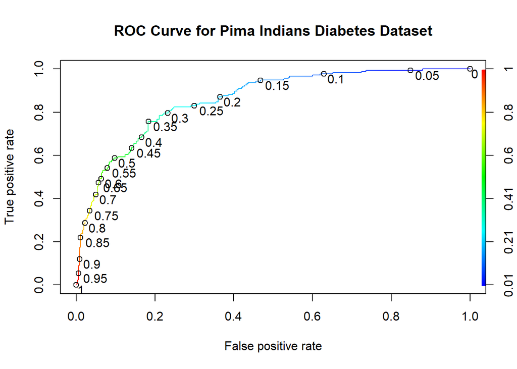

```r
# First argument is the probabilities extracted using fitted() or predict()
# Second argument is the classification labels with same dimensions as first argument
# Third argument is the order, with first label being negative, second being positive class
ROCRpred <- ROCR::prediction(predictions = prob.model2, labels = data$diabetes, label.ordering = c("neg" , "pos"))

# Performance based on true positive rate and false positive rate (ROC curve)
ROCperf <- ROCR::performance(prediction.obj = ROCRpred, measure = "tpr", x.measure = "fpr")

# Plot ROC Curve and indicate threshold value
plot(ROCperf,
     colorize = T,
     print.cutoffs.at = seq(0, by = 0.05),
     text.adj = c(-0.2, 1),
     main = "ROC Curve for Pima Indians Diabetes Dataset")
```

From the ROC curve, we can see the trade-off between TPR and FPR at different probability thresholds. If we do not mind having more false positives, we can increase the number of true positives detected by the model by using a threshold lower than 0.5, for example at 0.35 to keep the FPR around 0.2 but increasing the TPR to about 0.75-0.8. However, as discussed previously, false negatives are much more of a concern to us since the purpose of the model is to predict if a person is diabetic or not. In such cases, we should use another plot called the Precision-Recall Curve (particularly in cases where there are class imbalances.)

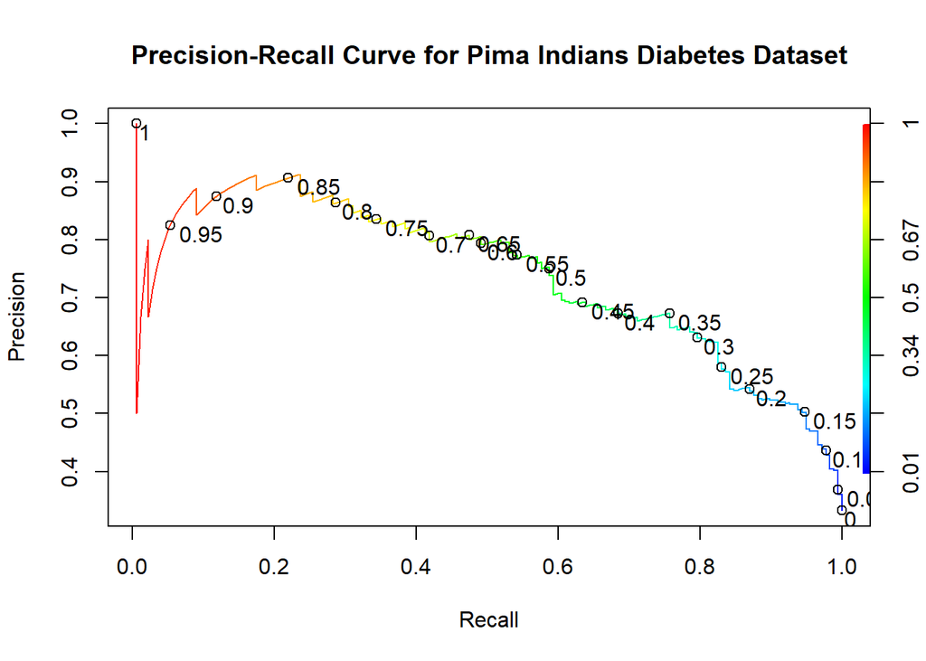

```r
# Performance based on precision and recall
Precperf <- ROCR::performance(prediction.obj = ROCRpred, measure = "prec", x.measure = "rec")

# Plot Precision-Recall Curve with threshold values
plot(Precperf,
     colorize = T,
     print.cutoffs.at = seq(0, by = 0.05),
     text.adj = c(-0.2, 1),
     main = "Precision-Recall Curve for Pima Indians Diabetes Dataset")
```

Based on the trade-off between the Precision and Recall scores, we could have the threshold at 0.35 since it greatly increases Recall (better when FN are more costly that FP) while leading to a slight reduction in Precision. Let us use the confusion matrix to evaluate if this probability threshold is better than using 0.5.

```r
new_pred.model2 <- as.factor(ifelse(prob.model2 > 0.35, "pos", "neg"))

confusionMatrix(data = new_pred.model2,
                reference = data$diabetes,
                dnn = c("Predicted", "Actual"),
                positive = "pos", mode = "everything")
```

```
## Confusion Matrix and Statistics
##
##          Actual
## Predicted neg pos
##       neg 290  43
##       pos  65 134
##
##                Accuracy : 0.797
##                  95% CI : (0.7603, 0.8304)
##     No Information Rate : 0.6673
##     P-Value [Acc > NIR] : 2.527e-11
##
##                   Kappa : 0.5566
##
##  Mcnemar's Test P-Value : 0.04331
##
##             Sensitivity : 0.7571
##             Specificity : 0.8169
##          Pos Pred Value : 0.6734
##          Neg Pred Value : 0.8709
##               Precision : 0.6734
##                  Recall : 0.7571
##                      F1 : 0.7128
##              Prevalence : 0.3327
##          Detection Rate : 0.2519
##    Detection Prevalence : 0.3741
##       Balanced Accuracy : 0.7870
##
##        'Positive' Class : pos
##
```

By changing the threshold, I was able to decrease the number of False Negatives and increase the number of True Positives. However, this came at the cost of reduced True Negatives and increased False Positives. There are definitely more sophisticated methods to determine the appropriate threshold values, but these are the simpler methods that can be applied.

## 6 Dealing With Imbalanced Datasets

In Section 3.1 Exploratory Data Analysis, the plot of the distribution of the class *`diabetes`* revealed that there are about twice as many negative observations than positive observations. While this might not be considered a serious imbalanced dataset, we do have lesser observations of one class compared to the other. It is not uncommon for datasets to have more observations of one class compared to another due to their natural rate of occurrence and sampling techniques. Imbalanced datasets pose the risk of biased prediction as it can identify the majority class more easily than the minority class.

The three common techniques to deals with this issue are under-sampling, over-sampling and synthetic minority over-sampling technique (SMOTE). Under-sampling randomly removes observations of the majority class while over-sampling randomly replicates observations of the minority class to balance the dataset. Under-sampling reduces information about the majority class while over-sampling simply replicates observations which could lead to overfitting. SMOTE is another over-sampling method but instead of replicating the observations, it creates artificial data with respect to the minority class by using the nearest neighbor technique between the minority class.

The **`ROSE`** package can be used for under-sampling and over-sampling the dataset, while the **`smotefamily`** package can be used for SMOTE. In our original data, we had 355 negative observations and 177 positive observations, and we can compare how it has changed after the re-sampling is done.

### Under-Sampling Method

```r
# Argument 1 indicates the class vs all other variables in the dataset
# Argument 2 indicates where to find the data
# Argument 3 indicates whether to over- or under-sample
# Argument 4 indicates target number of observations, in this case I put 2 times of the minority class

undersample <- ROSE::ovun.sample(diabetes ~ .,
                                 data = data,
                                 method = "under",
                                 N = 177*2)

summary(undersample)
```

```
##
## Call:
## ROSE::ovun.sample(formula = diabetes ~ ., data = data, method = "under",
##     N = 177 * 2)
##
## Summary of data balanced by undersampling
##
##     pregnant         glucose         pressure         triceps
##  Min.   : 0.000   Min.   : 57.0   Min.   : 24.00   Min.   : 7.00
##  1st Qu.: 1.000   1st Qu.:100.2   1st Qu.: 64.00   1st Qu.:23.25
##  Median : 3.000   Median :120.0   Median : 72.00   Median :30.00
##  Mean   : 3.797   Mean   :126.6   Mean   : 71.94   Mean   :30.38
##  3rd Qu.: 6.000   3rd Qu.:150.8   3rd Qu.: 80.00   3rd Qu.:37.00
##  Max.   :17.000   Max.   :199.0   Max.   :110.00   Max.   :99.00
##     insulin           mass          pedigree           age        diabetes
##  Min.   :  0.0   Min.   :19.30   Min.   :0.0850   Min.   :21.00   neg:177
##  1st Qu.: 15.0   1st Qu.:29.30   1st Qu.:0.2692   1st Qu.:24.00   pos:177
##  Median :105.0   Median :33.60   Median :0.4265   Median :29.00
##  Mean   :126.5   Mean   :33.82   Mean   :0.5275   Mean   :32.66
##  3rd Qu.:176.0   3rd Qu.:37.40   3rd Qu.:0.6777   3rd Qu.:40.00
##  Max.   :846.0   Max.   :67.10   Max.   :2.4200   Max.   :70.00
```

### Over-Sampling Method

```r
# For over-sampling, I indicate 2 times of majority class for target number of observations

oversample <- ROSE::ovun.sample(diabetes ~ .,
                                data = data,
                                method = "over",
                                N = 355*2)

summary(oversample)
```

```
##
## Call:
## ROSE::ovun.sample(formula = diabetes ~ ., data = data, method = "over",
##     N = 355 * 2)
##
## Summary of data balanced by oversampling
##
##     pregnant         glucose         pressure        triceps
##  Min.   : 0.000   Min.   : 56.0   Min.   : 24.0   Min.   : 7.00
##  1st Qu.: 1.000   1st Qu.:101.0   1st Qu.: 64.0   1st Qu.:23.00
##  Median : 3.000   Median :121.5   Median : 72.0   Median :30.00
##  Mean   : 3.925   Mean   :127.0   Mean   : 72.6   Mean   :30.37
##  3rd Qu.: 6.000   3rd Qu.:151.0   3rd Qu.: 82.0   3rd Qu.:37.00
##  Max.   :17.000   Max.   :199.0   Max.   :110.0   Max.   :99.00
##     insulin           mass          pedigree           age        diabetes
##  Min.   :  0.0   Min.   :18.20   Min.   :0.0850   Min.   :21.00   neg:355
##  1st Qu.:  0.0   1st Qu.:28.90   1st Qu.:0.2632   1st Qu.:24.00   pos:355
##  Median :105.0   Median :33.60   Median :0.4440   Median :29.00
##  Mean   :125.9   Mean   :33.49   Mean   :0.5321   Mean   :33.08
##  3rd Qu.:179.5   3rd Qu.:37.38   3rd Qu.:0.6920   3rd Qu.:41.00
##  Max.   :846.0   Max.   :67.10   Max.   :2.4200   Max.   :81.00
```

### SMOTE Method

```r
# X refers to data frame or matrix containing numeric-attributed explanatory variables
# target refers to vector of the class corresponding to X
# K = 5 is the default number of nearest neighbors, SMOTE uses KNN to generate artificial data
# dup_size refers to the multiples of minority observations compared to majority observations
# In this case, 1 means to generate 1 minority for 1 majority observation

smote <- smotefamily::SMOTE(X = explvar,
                            target = response,
                            K = 5,
                            dup_size = 1)

# Extract the newly generated data set that contains both the synthetic and original observations
smote_data <- smote$data

summary(smote_data)
```

```
##     pregnant        glucose         pressure         triceps
##  Min.   : 0.00   Min.   : 56.0   Min.   : 24.00   Min.   : 7.00
##  1st Qu.: 1.00   1st Qu.:101.0   1st Qu.: 64.00   1st Qu.:23.00
##  Median : 3.00   Median :122.0   Median : 72.00   Median :30.00
##  Mean   : 3.89   Mean   :126.6   Mean   : 72.28   Mean   :30.03
##  3rd Qu.: 6.00   3rd Qu.:151.0   3rd Qu.: 80.00   3rd Qu.:36.54
##  Max.   :17.00   Max.   :199.0   Max.   :110.00   Max.   :99.00
##     insulin           mass          pedigree           age
##  Min.   :  0.0   Min.   :18.20   Min.   :0.0850   Min.   :21.00
##  1st Qu.:  0.0   1st Qu.:29.28   1st Qu.:0.2800   1st Qu.:24.00
##  Median :105.0   Median :33.40   Median :0.4520   Median :29.51
##  Mean   :123.6   Mean   :33.55   Mean   :0.5324   Mean   :32.83
##  3rd Qu.:176.0   3rd Qu.:37.20   3rd Qu.:0.6847   3rd Qu.:40.00
##  Max.   :846.0   Max.   :67.10   Max.   :2.4200   Max.   :81.00
##     class
##  Length:709
##  Class :character
##  Mode  :character
##
##
##
```

```r
# diabetes variable has been replaced by class and is in character class, need to change it to factor
smote_data$class <- factor(smote_data$class)

summary(smote_data)
```

```
##     pregnant        glucose         pressure         triceps
##  Min.   : 0.00   Min.   : 56.0   Min.   : 24.00   Min.   : 7.00
##  1st Qu.: 1.00   1st Qu.:101.0   1st Qu.: 64.00   1st Qu.:23.00
##  Median : 3.00   Median :122.0   Median : 72.00   Median :30.00
##  Mean   : 3.89   Mean   :126.6   Mean   : 72.28   Mean   :30.03
##  3rd Qu.: 6.00   3rd Qu.:151.0   3rd Qu.: 80.00   3rd Qu.:36.54
##  Max.   :17.00   Max.   :199.0   Max.   :110.00   Max.   :99.00
##     insulin           mass          pedigree           age        class
##  Min.   :  0.0   Min.   :18.20   Min.   :0.0850   Min.   :21.00   neg:355
##  1st Qu.:  0.0   1st Qu.:29.28   1st Qu.:0.2800   1st Qu.:24.00   pos:354
##  Median :105.0   Median :33.40   Median :0.4520   Median :29.51
##  Mean   :123.6   Mean   :33.55   Mean   :0.5324   Mean   :32.83
##  3rd Qu.:176.0   3rd Qu.:37.20   3rd Qu.:0.6847   3rd Qu.:40.00
##  Max.   :846.0   Max.   :67.10   Max.   :2.4200   Max.   :81.00
```

### 6.1 Evaluating the Performance of Under-Sampling Method

To evaluate the performance of these different sampling techniques, I estimated a restricted model just like Model 2 and used a cut-off probability of 0.5 to make it easily comparable to the scores of Model 2 in Section 4.

```r
model4 <- glm(diabetes == "pos" ~ pregnant + glucose + mass + pedigree,
              data = undersample$data,
              family = binomial(link = "logit"))

stargazer(model4,
          type = "text",
          title = "Logit Regression Output for Under-Sampling Method")
```

```
##
## Logit Regression Output for Under-Sampling Method
## =============================================
##                       Dependent variable:
##                   ---------------------------
##                        diabetes == "pos"
## ---------------------------------------------
## pregnant                   0.179***
##                             (0.041)
##
## glucose                    0.037***
##                             (0.005)
##
## mass                       0.094***
##                             (0.022)
##
## pedigree                   1.386***
##                             (0.440)
##
## Constant                   -9.180***
##                             (1.076)
##
## ---------------------------------------------
## Observations                  354
## Log Likelihood             -168.954
## Akaike Inf. Crit.           347.908
## =============================================
## Note:             *p<0.1; **p<0.05; ***p<0.01
```

```r
prob.model4 <- predict(model4, type = "response")

prediction.model4 <- as.factor(ifelse(prob.model4 > 0.5, "pos", "neg"))

confusionMatrix(data = prediction.model4,
                reference = undersample$data$diabetes,
                dnn = c("Predicted", "Actual"),
                positive = "pos", mode = "everything")
```

```
## Confusion Matrix and Statistics
##
##          Actual
## Predicted neg pos
##       neg 143  41
##       pos  34 136
##
##                Accuracy : 0.7881
##                  95% CI : (0.7418, 0.8295)
##     No Information Rate : 0.5
##     P-Value [Acc > NIR] : <2e-16
##
##                   Kappa : 0.5763
##
##  Mcnemar's Test P-Value : 0.4884
##
##             Sensitivity : 0.7684
##             Specificity : 0.8079
##          Pos Pred Value : 0.8000
##          Neg Pred Value : 0.7772
##               Precision : 0.8000
##                  Recall : 0.7684
##                      F1 : 0.7839
##              Prevalence : 0.5000
##          Detection Rate : 0.3842
##    Detection Prevalence : 0.4802
##       Balanced Accuracy : 0.7881
##
##        'Positive' Class : pos
##
```

### 6.2 Evaluating the Performance of Over-Sampling Method

```r
model5 <- glm(diabetes == "pos" ~ pregnant + glucose + mass + pedigree,
              data = oversample$data,
              family = binomial(link = "logit"))

stargazer(model5,
          type = "text",
          title = "Logit Regression Output for Over-Sampling Method")
```

```
##
## Logit Regression Output for Over-Sampling Method
## =============================================
##                       Dependent variable:
##                   ---------------------------
##                        diabetes == "pos"
## ---------------------------------------------
## pregnant                   0.200***
##                             (0.030)
##
## glucose                    0.037***
##                             (0.004)
##
## mass                       0.093***
##                             (0.016)
##
## pedigree                   1.695***
##                             (0.319)
##
## Constant                   -9.497***
##                             (0.779)
##
## ---------------------------------------------
## Observations                  710
## Log Likelihood             -328.379
## Akaike Inf. Crit.           666.758
## =============================================
## Note:             *p<0.1; **p<0.05; ***p<0.01
```

```r
prob.model5 <- predict(model5, type = "response")

prediction.model5 <- as.factor(ifelse(prob.model5 > 0.5, "pos", "neg"))

confusionMatrix(data = prediction.model5,
                reference = oversample$data$diabetes,
                dnn = c("Predicted", "Actual"),
                positive = "pos", mode = "everything")
```

```
## Confusion Matrix and Statistics
##
##          Actual
## Predicted neg pos
##       neg 286  86
##       pos  69 269
##
##                Accuracy : 0.7817
##                  95% CI : (0.7495, 0.8116)
##     No Information Rate : 0.5
##     P-Value [Acc > NIR] : <2e-16
##
##                   Kappa : 0.5634
##
##  Mcnemar's Test P-Value : 0.1987
##
##             Sensitivity : 0.7577
##             Specificity : 0.8056
##          Pos Pred Value : 0.7959
##          Neg Pred Value : 0.7688
##               Precision : 0.7959
##                  Recall : 0.7577
##                      F1 : 0.7763
##              Prevalence : 0.5000
##          Detection Rate : 0.3789
##    Detection Prevalence : 0.4761
##       Balanced Accuracy : 0.7817
##
##        'Positive' Class : pos
##
```

### 6.3 Evaluating the Performance of SMOTE Method

```r
model6 <- glm(class == "pos" ~ pregnant + glucose + mass + pedigree,
              data = smote_data,
              family = binomial(link = "logit"))

stargazer(model6,
          type = "text",
          title = "Logit Regression Output for SMOTE Method")
```

```
##
## Logit Regression Output for SMOTE Method
## =============================================
##                       Dependent variable:
##                   ---------------------------
##                         class == "pos"
## ---------------------------------------------
## pregnant                   0.192***
##                             (0.031)
##
## glucose                    0.037***
##                             (0.004)
##
## mass                       0.089***
##                             (0.016)
##
## pedigree                   1.547***
##                             (0.321)
##
## Constant                   -9.153***
##                             (0.757)
##
## ---------------------------------------------
## Observations                  709
## Log Likelihood             -334.014
## Akaike Inf. Crit.           678.029
## =============================================
## Note:             *p<0.1; **p<0.05; ***p<0.01
```

```r
prob.model6 <- predict(model6, type = "response")

prediction.model6 <- as.factor(ifelse(prob.model6 > 0.5, "pos", "neg"))

confusionMatrix(data = prediction.model6,
                reference = smote_data$class,
                dnn = c("Predicted", "Actual"),
                positive = "pos", mode = "everything")
```

```
## Confusion Matrix and Statistics
##
##          Actual
## Predicted neg pos
##       neg 283  89
##       pos  72 265
##
##                Accuracy : 0.7729
##                  95% CI : (0.7403, 0.8033)
##     No Information Rate : 0.5007
##     P-Value [Acc > NIR] : <2e-16
##
##                   Kappa : 0.5458
##
##  Mcnemar's Test P-Value : 0.2073
##
##             Sensitivity : 0.7486
##             Specificity : 0.7972
##          Pos Pred Value : 0.7864
##          Neg Pred Value : 0.7608
##               Precision : 0.7864
##                  Recall : 0.7486
##                      F1 : 0.7670
##              Prevalence : 0.4993
##          Detection Rate : 0.3738
##    Detection Prevalence : 0.4753
##       Balanced Accuracy : 0.7729
##
##        'Positive' Class : pos
##
```

However, what I did not do was to test out-of-sample prediction since I wanted this to be an introduction to the methods of binary classification using logistic regression. I will provide a more comprehensive application of logistic regression in binary classification in another project using another dataset that would be more challenging, with the imbalance more heavily skewed to one class than the other.

## References

https://www.statisticssolutions.com/free-resources/directory-of-statistical-analyses/assumptions-of-logistic-regression/

https://towardsdatascience.com/assumptions-of-logistic-regression-clearly-explained-44d85a22b290

https://www.statology.org/assumptions-of-logistic-regression/

https://www.theanalysisfactor.com/outliers-to-drop-or-not-to-drop/

https://ademos.people.uic.edu/Chapter22.html

https://developers.google.com/machine-learning/crash-course/classification/roc-and-auc

https://machinelearningmastery.com/roc-curves-and-precision-recall-curves-for-classification-in-python/#:~:text=A%20precision%2Drecall%20curve%20is,constant%20class%20in%20all%20cases.

https://www.analyticsvidhya.com/blog/2016/03/practical-guide-deal-imbalanced-classification-problems/